# ASD Risk Screening: Comparative Evaluation of Statistical Learning Methods

ISyE 7406 – Data Mining & Statistical Learning | Midterm Report

Abdurrahman Sabbahi | asabbahi3@gatech.edu | Georgia Tech

July 2026

# 1 Introduction

Autism Spectrum Disorder (ASD) affects roughly 1 in 36 children in the United States, yet the average time from parental concern to a confirmed diagnosis can stretch across years. Going through that process with my son — filling in questionnaires and not fully understanding what the numbers meant — motivated the research question: *how much predictive information actually sits in those ten screening responses?*

The AQ-10 is a ten-item behavioral questionnaire used as a first-pass screener for ASD across three developmental stages. This report compares five classifiers on separate Child, Adolescent, and Adult datasets, as well as the three combined, asking four questions: (1) which model performs best overall, (2) whether performance varies meaningfully by age group, (3) which features carry the most predictive signal, and (4) whether the ten AQ items alone are sufficient or whether demographic variables contribute additional value.

**Methodology in brief.** The data are split 80/20 (stratified by outcome) once. Five-fold cross-validation on the training portion is used exclusively for model selection and hyperparameter tuning. The held-out test set is evaluated exactly once, at the end, and plays no role in any model selection decision. Feature scaling is fit inside each CV training fold — never on the full dataset — to prevent data leakage.

# 2 Data

## 2.1 Source

Three datasets from Fadi Fayez Thabtah (UCI / Kaggle), one per developmental stage, all collected with the same AQ-10 screening protocol. Each record corresponds to one individual who completed the screener.

## 2.2 Overview

Dataset summary by age group.

| Group | Age range | N | ASD+ (%) |
| --- | --- | --- | --- |
| Child | 4–11 | 292 | 48.3 |
| Adolescent | 12–16 | 104 | 60.6 |
| Adult | 17+ | 704 | 26.8 |
| **Combined** | – | 1100 | 35.7 |

## 2.3 Descriptive Statistics

Descriptive statistics (full dataset, before the train/test split).

| Dataset | N | ASD+ (%) | AQ Mean | AQ SD | Age Mean | Male (%) | Jaundice (%) | Fam Hx ASD (%) |
| --- | --- | --- | --- | --- | --- | --- | --- | --- |
| Child | 292 | 48.3 | 6.24 | 2.28 | 6.3 | 71.2 | 27.4 | 16.8 |
| Adolescent | 104 | 60.6 | 6.72 | 2.20 | 14.1 | 48.1 | 15.4 | 13.5 |
| Adult | 704 | 26.8 | 4.88 | 2.50 | 29.7 | 52.1 | 9.8 | 12.9 |
| Combined | 1100 | 35.7 | 5.41 | 2.52 | 22.0 | 56.8 | 15.0 | 14.0 |

The adult dataset (n = 704) is the largest and most imbalanced — only 27% ASD positive. The adolescent set (n = 104) is the smallest; those results should be interpreted with extra caution. The AQ mean is consistently higher in positive cases across all groups, which is an early indication of predictive signal.

## 2.4 Preprocessing

Raw missing values (`"?"` and blank strings) were replaced with `NA` on import. Age was the only column with missingness (three observations); these were imputed using the group-specific median computed from the training set. The `result` column (raw AQ sum) and any ID columns were dropped immediately, since keeping them would give the models the answer directly.

Binary variables (gender, jaundice history, family ASD history, prior app use) were recoded to 0/1. Unordered nominal factors — ethnicity, country of residence, and relation — were expanded into binary dummy columns using `model.matrix`, which avoids imposing a false ordinal ordering that integer encoding would introduce. Feature scaling to zero mean and unit variance is applied inside every CV fold and every final model fit — never on the full dataset — so no information from the validation or test observations leaks into the scaling parameters.

# 3 Exploratory Data Analysis

## 3.1 Class Balance

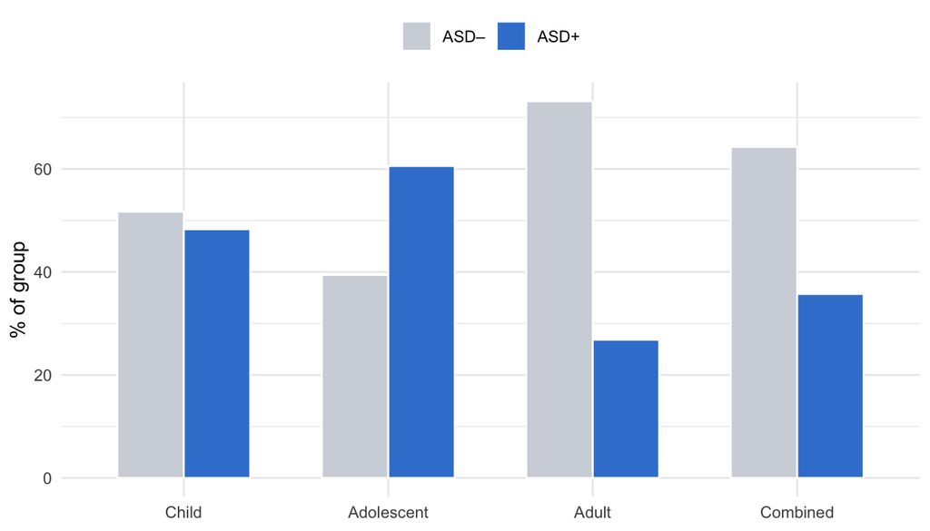

The adolescent group is approximately 61% positive while the adult group is only 27% positive. Stratified cross-validation accounts for this imbalance, but it is the reason raw accuracy is a misleading metric here — AUC and recall are the appropriate measures to focus on.

## 3.2 AQ-10 Score Distribution

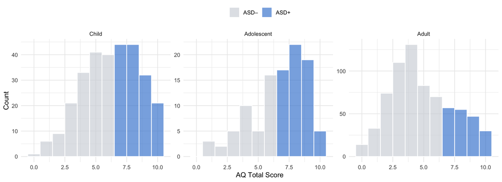

AQ-10 total score by ASD outcome. ASD-positive cases score consistently higher across all three age groups, with the sharpest separation in the child dataset.

The AQ total score separates ASD-positive from ASD-negative cases well in all three groups. The child group shows the sharpest separation. Most misclassifications occur in the 4–7 score range, where the distributions overlap. This approximately linear separation is part of the reason logistic regression turns out to be competitive with ensemble methods.

## 3.3 Correlation Structure

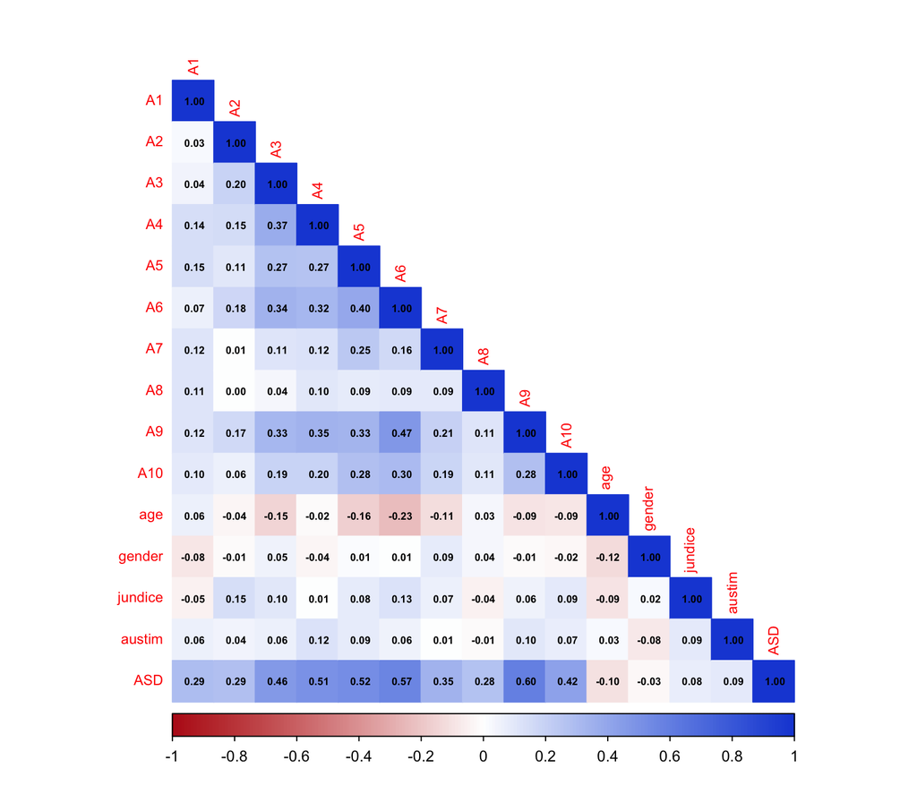

Pearson correlation matrix for AQ items, binary demographic variables, and the ASD outcome (combined encoded dataset). AQ items correlate consistently with the outcome; demographic correlations are weaker.

All ten AQ items correlate positively with the outcome. The A3–A6 cluster shows moderate inter-item correlation. Demographic variables (age, gender, jaundice, family history) have much weaker correlations with the outcome — a preview of what the chi-square and importance analyses confirm later.

## 3.4 Chi-Square Feature Ranking

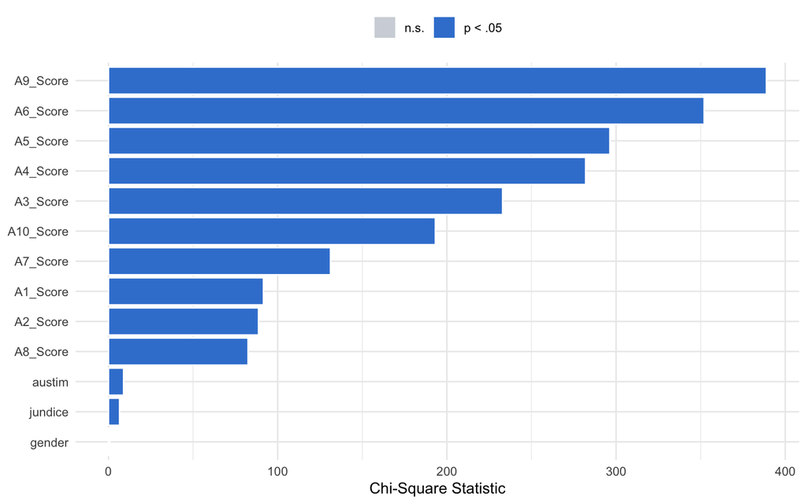

Chi-square test results for features against ASD outcome.

| Feature | Chi2 | p |
| --- | --- | --- |
| A9_Score | 388.87 | < 0.001 |
| A6_Score | 352.05 | < 0.001 |
| A5_Score | 296.36 | < 0.001 |
| A4_Score | 282.02 | < 0.001 |
| A3_Score | 232.96 | < 0.001 |
| A10_Score | 193.20 | < 0.001 |
| A7_Score | 131.21 | < 0.001 |
| A1_Score | 91.58 | < 0.001 |
| A2_Score | 88.68 | < 0.001 |
| A8_Score | 82.50 | < 0.001 |
| austim | 8.93 | 0.003 |
| jundice | 6.57 | 0.010 |
| gender | 0.75 | 0.388 |

All ten AQ items are highly significant (p < 0.001). Of the demographic variables, jaundice history and family ASD history (`austim`) are marginally significant; gender is not (p = 0.388). The agreement between chi-square rankings and the Random Forest variable importance results presented in Section 4.6 provides independent evidence that the AQ items consistently carry the strongest predictive signal. This pattern also motivated the full-versus-AQ-only comparison in Section 4.7.

## 3.5 PCA

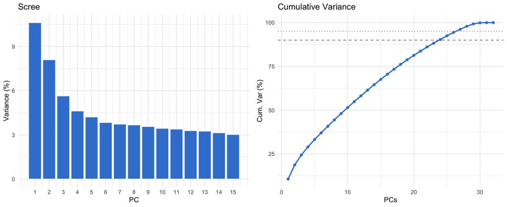

Scree plot (left) and cumulative variance explained (right) for the combined training set. The variance is distributed across many principal components, indicating that the information in the predictors is not concentrated in only a few linear combinations.

It takes 24 principal components to explain 90% of the variance — a large number for a dataset of this feature dimensionality. The variance is distributed across many principal components, indicating that the information in the predictors is not concentrated in only a few linear combinations.

# 4 Modeling

## 4.1 Methodology

**Why these five models.** The five classifiers were chosen to cover a spectrum from simple linear baselines to flexible non-parametric and ensemble approaches:

| Model | Rationale |
| --- | --- |
| Logistic Regression | Interpretable linear baseline; directly models log-odds of ASD |
| LDA | Generative linear model; useful comparator to LR under Gaussian assumptions |
| Naive Bayes | Tests how far the conditional independence assumption departs from reality |
| KNN | Non-parametric, distance-based; no linearity assumption, sensitive to scale |
| Random Forest | Flexible ensemble; captures feature interactions without manual specification |

Including both linear models (LR, LDA) and non-parametric/ensemble models (KNN, RF) makes it possible to tell whether any non-linearity in the data is actually worth capturing, or whether a simple linear boundary is sufficient.

**Evaluation pipeline:**

1. Stratified 80/20 train/test split (done once, before any modeling)
2. Five-fold CV on the training data — used exclusively for model selection and hyperparameter tuning
3. Final models refit on the full training set using tuned hyperparameters
4. Evaluated once on the held-out test set

Hyperparameter tuning was performed exclusively within the training data using five-fold cross-validation. The held-out test set was not used during model selection or tuning in any way.

Primary metric: **AUC** (threshold-independent, appropriate for imbalanced classes). Secondary: **Recall** — missing a true ASD-positive case is the costlier error in a clinical screening context.

## 4.2 5-Fold CV Results (Training Data)

5-fold cross-validation performance on the training data (full feature set). Results are used to select the best model per group; the test set was not consulted.

| Model | AUC | Acc | Rec | Prec | Spec | F1 |
| --- | --- | --- | --- | --- | --- | --- |
| **Child** |  |  |  |  |  |  |
| Logistic Reg. | 0.998 | 0.966 | 0.949 | 0.982 | 0.982 | 0.965 |
| Random Forest | 0.984 | 0.923 | 0.952 | 0.885 | 0.884 | 0.917 |
| Naive Bayes | 0.982 | 0.726 | 0.643 | 0.973 | 0.974 | 0.775 |
| KNN (k=5) | 0.934 | 0.838 | 0.782 | 0.920 | 0.920 | 0.846 |
| **Adolescent** |  |  |  |  |  |  |
| Naive Bayes | 0.972 | 0.643 | 0.630 | 1.000 | 1.000 | 0.773 |
| Random Forest | 0.960 | 0.857 | 0.831 | 0.961 | 0.960 | 0.891 |
| Logistic Reg. | 0.892 | 0.821 | 0.875 | 0.824 | 0.827 | 0.848 |
| KNN (k=5) | 0.871 | 0.750 | 0.727 | 0.941 | 0.940 | 0.821 |
| **Adult** |  |  |  |  |  |  |
| Logistic Reg. | 0.996 | 0.988 | 0.956 | 1.000 | 1.000 | 0.977 |
| Random Forest | 0.993 | 0.947 | 0.977 | 0.822 | 0.821 | 0.893 |
| Naive Bayes | 0.989 | 0.918 | 0.801 | 0.928 | 0.927 | 0.860 |
| KNN (k=5) | 0.946 | 0.895 | 0.789 | 0.836 | 0.835 | 0.812 |
| **Combined** |  |  |  |  |  |  |
| Logistic Reg. | 1.000 | 1.000 | 1.000 | 1.000 | 1.000 | 1.000 |
| LDA | 0.996 | NA | 0.920 | 0.974 | 0.974 | 0.946 |
| Random Forest | 0.993 | 0.948 | 0.950 | 0.902 | 0.902 | 0.925 |
| Naive Bayes | 0.986 | 0.754 | 0.594 | 0.987 | 0.987 | 0.741 |
| KNN (k=5) | 0.955 | 0.896 | 0.814 | 0.917 | 0.917 | 0.863 |

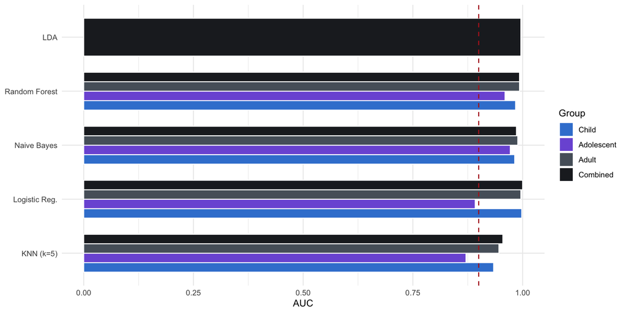

## 4.3 ROC Curves

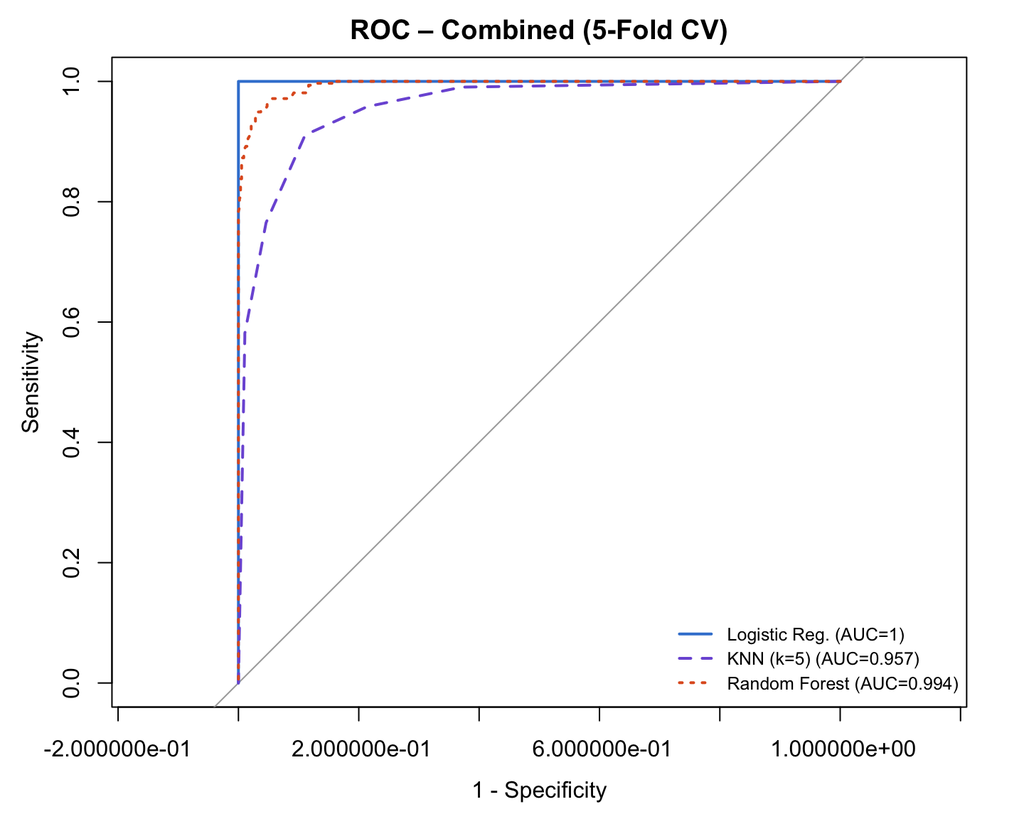

## 4.4 Hyperparameter Tuning

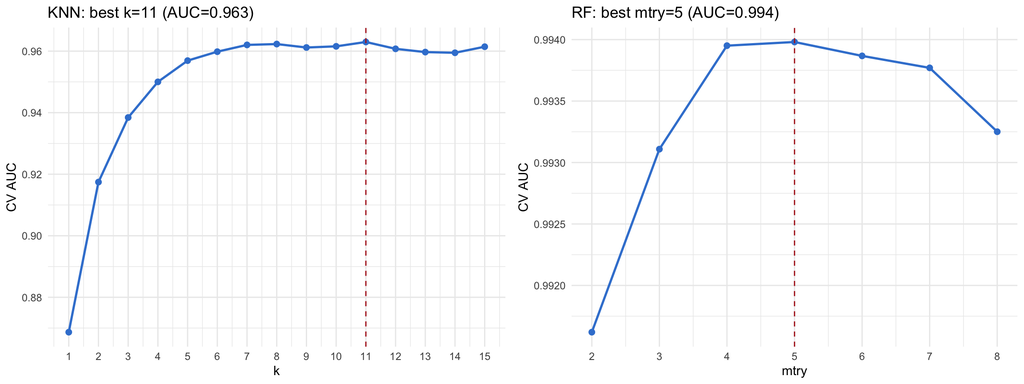

Left: KNN CV AUC as a function of k; right: RF CV AUC as a function of mtry. Dashed vertical lines mark the selected values. Both searches were conducted exclusively on the combined training set.

KNN’s best k = **11** (CV AUC = 0.963). The instability at k = 1 is the expected signature of overfitting, and AUC plateaus at higher k — the classic KNN tuning shape.

Random Forest’s best mtry = **5** (CV AUC = 0.994). The RF curve is relatively flat across the mtry range, suggesting the tuning decision has limited impact here compared with KNN.

## 4.5 Regularized Logistic Regression

Unregularized LR achieved AUC = 1 on the combined training set. That near-perfect result warrants scrutiny — it could reflect genuine near-linear separability, or it could be an artifact of the age-group label being recoverable from the feature space. Elastic-net regularization (sweeping both alpha and lambda) tests whether coefficient shrinkage changes anything.

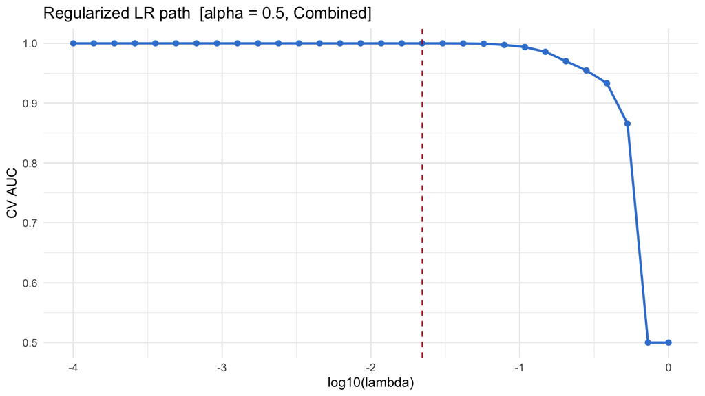

Regularized logistic regression CV AUC along the penalty path (best alpha shown). AUC remains near 1.0 across several orders of magnitude of lambda before collapsing at very large penalties.

Best regularized LR: alpha = 0.5, lambda = 0.0221, CV AUC = **1**. Regularization produced nearly identical predictive performance to the unregularized model, suggesting that the strong logistic regression results were not simply caused by unstable coefficient estimates. The data appears to be genuinely close to linearly separable in this feature space.

## 4.6 RF Variable Importance

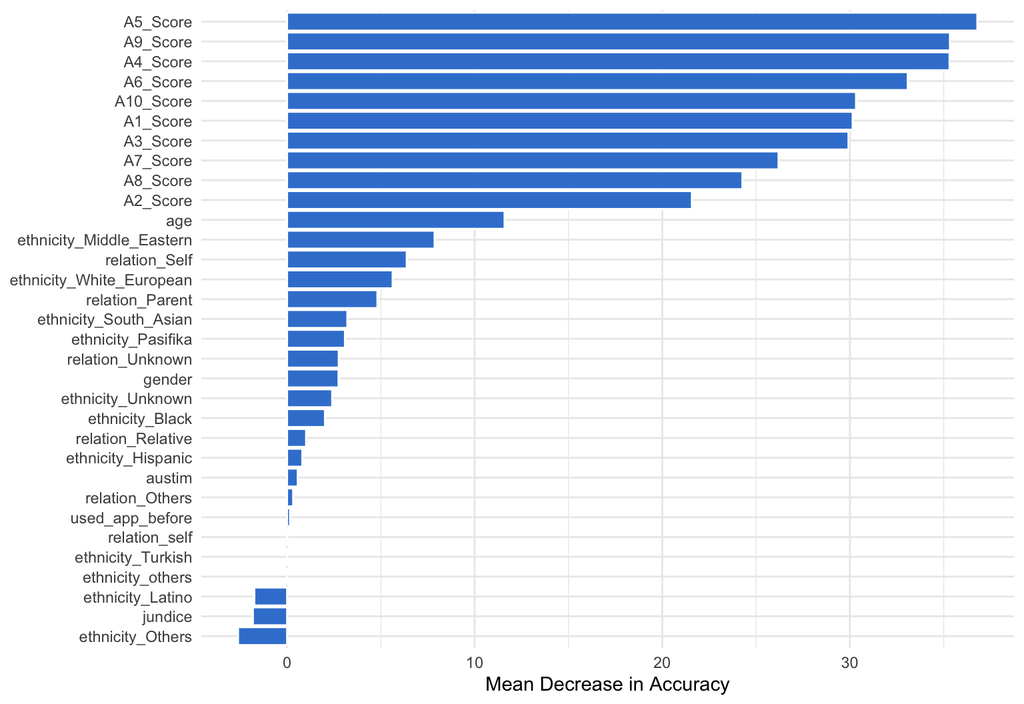

Random Forest variable importance (Mean Decrease in Accuracy) trained on the combined training set. AQ items dominate; demographic variables sit well below any AQ item.

Top 10 features by RF Mean Decrease in Accuracy.

| Feature | MDA |
| --- | --- |
| A5_Score | 36.79 |
| A9_Score | 35.33 |
| A4_Score | 35.31 |
| A6_Score | 33.08 |
| A10_Score | 30.32 |
| A1_Score | 30.14 |
| A3_Score | 29.92 |
| A7_Score | 26.19 |
| A8_Score | 24.27 |
| A2_Score | 21.57 |

## 4.7 Full vs AQ-Only Feature Set

If demographic variables contribute limited additional predictive information, a screener relying only on the ten AQ items may be sufficient — and would be simpler, more equitable, and easier to deploy in practice.

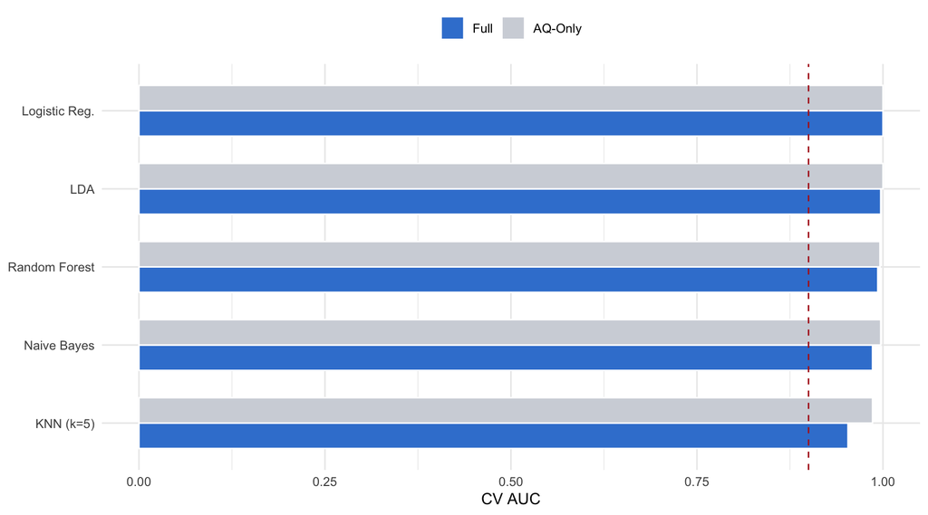

CV AUC comparison: full feature set vs. AQ items only (combined dataset). For most models the two feature sets perform nearly identically, with no consistent advantage to including demographic variables.

Full feature set vs. AQ-only on the combined dataset (5-fold CV).

| Model | FeatSet | AUC | Acc | Rec | Spec | F1 |
| --- | --- | --- | --- | --- | --- | --- |
| KNN (k=5) | AQ-Only | 0.986 | 0.942 | 0.888 | 0.959 | 0.922 |
| KNN (k=5) | Full | 0.953 | 0.888 | 0.807 | 0.902 | 0.852 |
| LDA | AQ-Only | 1.000 | 0.981 | 0.949 | 1.000 | 0.974 |
| LDA | Full | 0.997 | NA | 0.921 | 0.984 | 0.951 |
| Logistic Reg. | AQ-Only | 1.000 | 1.000 | 1.000 | 1.000 | 1.000 |
| Logistic Reg. | Full | 1.000 | 1.000 | 1.000 | 1.000 | 1.000 |
| Naive Bayes | AQ-Only | 0.997 | 0.922 | 0.820 | 1.000 | 0.901 |
| Naive Bayes | Full | 0.986 | 0.765 | 0.603 | 1.000 | 0.753 |
| Random Forest | AQ-Only | 0.996 | 0.966 | 0.964 | 0.940 | 0.952 |
| Random Forest | Full | 0.993 | 0.953 | 0.963 | 0.905 | 0.933 |

For most models, the AQ-only set matches or marginally exceeds the full feature set. Removing demographics does not degrade performance and occasionally helps, particularly in the adolescent group where small sample size amplifies noise from high-cardinality nominal columns. From a practical perspective, demographic variables contributed limited additional predictive information in these datasets, and the ten-item AQ screener may be sufficient within these datasets.

# 5 Final Test Set Results

Models were refit on the full training split using hyperparameters selected by cross-validation (KNN k = 11, RF mtry = 5), then evaluated exactly once on the held-out 20% test set. No model selection decisions were made based on test set performance.

Test performance of models selected using cross-validation. Each model was fit on the full training set with tuned hyperparameters and evaluated once on the held-out 20% test set.

| Model | AUC | Acc | Rec | Prec | F1 |
| --- | --- | --- | --- | --- | --- |
| **Child** |  |  |  |  |  |
| Logistic Reg. | 1.000 | 1.000 | 1.000 | 1.000 | 1.000 |
| Random Forest | 0.986 | 0.948 | 0.963 | 0.929 | 0.945 |
| KNN (tuned) | 0.923 | 0.741 | 0.659 | 0.964 | 0.783 |
| **Adolescent** |  |  |  |  |  |
| Logistic Reg. | 1.000 | 0.900 | 0.857 | 1.000 | 0.923 |
| Random Forest | 1.000 | 0.900 | 0.857 | 1.000 | 0.923 |
| KNN (tuned) | 0.839 | 0.750 | 0.706 | 1.000 | 0.828 |
| **Adult** |  |  |  |  |  |
| Logistic Reg. | 1.000 | 1.000 | 1.000 | 1.000 | 1.000 |
| Random Forest | 0.995 | 0.971 | 0.971 | 0.919 | 0.944 |
| KNN (tuned) | 0.969 | 0.900 | 0.811 | 0.811 | 0.811 |
| **Combined** |  |  |  |  |  |
| Logistic Reg. | 1.000 | 1.000 | 1.000 | 1.000 | 1.000 |
| LDA | 0.998 | 0.977 | 0.951 | 0.987 | 0.969 |
| Random Forest | 0.996 | 0.959 | 0.960 | 0.923 | 0.941 |
| KNN (tuned) | 0.950 | 0.886 | 0.835 | 0.846 | 0.841 |

# 6 Conclusions

**Age-group differences.** Performance is most stable and reliable on the adult dataset, which has the largest sample size. The adolescent group shows more variability between models — attributable largely to the small sample size (n = 104) rather than any fundamental difference in the underlying classification problem.

**Feature relevance.** AQ items carry almost all of the predictive signal. Demographic variables contributed limited additional predictive information in these datasets. The AQ-only models match the full feature set across all groups and all models, which is both a practical convenience and an equity consideration: a screener that relies only on behavioral items, not demographic proxies, is less susceptible to demographic bias.

**Regularization.** The near-perfect combined AUC is not a numerical artifact. Regularization produced nearly identical predictive performance, suggesting that the strong logistic regression results were not simply caused by unstable coefficient estimates. The data is genuinely close to linearly separable in this feature space.

**Limitations.**

- The 80/20 split was performed once; a single split introduces randomness into all point estimates. Results from the adolescent group (n = 104) are particularly sensitive to how the split falls.
- All three datasets were collected through the AQ-10 screening protocol specifically. People who were never referred for screening are absent, which introduces selection bias. The models should not be assumed to generalize to unscreened populations.
- No confidence intervals were computed; all conclusions are based on point estimates.
- The combined dataset includes an age column that may partially act as a group membership indicator when combined with AQ scores. A robustness check excluding age from the combined model would be worth running in a follow-up analysis.

**Future directions.** Several extensions would strengthen the conclusions. Adding uncertainty estimates — such as bootstrap confidence intervals for AUC — would clarify which performance differences are meaningful versus noise. Evaluating sensitivity and specificity at the clinical AQ-10 threshold (score ≥ 6) would connect the model output to the standard diagnostic cutpoint. Running repeated random subsampling rather than a single 80/20 split would reduce dependence on the particular split drawn. Finally, an analysis that explicitly excludes age-group membership from the combined model would test whether the near-perfect combined performance holds when that potential confound is removed.

# 7 Appendix

## 7.1 Software

R (v4.3+): `tidyverse`, `caret`, `randomForest`, `e1071`, `MASS`, `glmnet`, `pROC`, `corrplot`, `gridExtra`, `knitr`, `kableExtra`.

## 7.2 Complete CV Results

Complete 5-fold cross-validation results across all groups and models.

| Group | Model | AUC | Acc | Rec | Prec | F1 | Spec |
| --- | --- | --- | --- | --- | --- | --- | --- |
| Child | Logistic Reg. | 0.998 | 0.966 | 0.949 | 0.982 | 0.965 | 0.982 |
| Child | Random Forest | 0.984 | 0.923 | 0.952 | 0.885 | 0.917 | 0.884 |
| Child | Naive Bayes | 0.982 | 0.726 | 0.643 | 0.973 | 0.775 | 0.974 |
| Child | KNN (k=5) | 0.934 | 0.838 | 0.782 | 0.920 | 0.846 | 0.920 |
| Adolescent | Naive Bayes | 0.972 | 0.643 | 0.630 | 1.000 | 0.773 | 1.000 |
| Adolescent | Random Forest | 0.960 | 0.857 | 0.831 | 0.961 | 0.891 | 0.960 |
| Adolescent | Logistic Reg. | 0.892 | 0.821 | 0.875 | 0.824 | 0.848 | 0.827 |
| Adolescent | KNN (k=5) | 0.871 | 0.750 | 0.727 | 0.941 | 0.821 | 0.940 |
| Adult | Logistic Reg. | 0.996 | 0.988 | 0.956 | 1.000 | 0.977 | 1.000 |
| Adult | Random Forest | 0.993 | 0.947 | 0.977 | 0.822 | 0.893 | 0.821 |
| Adult | Naive Bayes | 0.989 | 0.918 | 0.801 | 0.928 | 0.860 | 0.927 |
| Adult | KNN (k=5) | 0.946 | 0.895 | 0.789 | 0.836 | 0.812 | 0.835 |
| Combined | Logistic Reg. | 1.000 | 1.000 | 1.000 | 1.000 | 1.000 | 1.000 |
| Combined | LDA | 0.996 | NA | 0.920 | 0.974 | 0.946 | 0.974 |
| Combined | Random Forest | 0.993 | 0.948 | 0.950 | 0.902 | 0.925 | 0.902 |
| Combined | Naive Bayes | 0.986 | 0.754 | 0.594 | 0.987 | 0.741 | 0.987 |
| Combined | KNN (k=5) | 0.955 | 0.896 | 0.814 | 0.917 | 0.863 | 0.917 |

## 7.3 Full Feature Comparison

Full feature set vs. AQ-only across all groups (5-fold CV).

| Group | Model | FeatSet | AUC | Acc | Rec | Spec | F1 |
| --- | --- | --- | --- | --- | --- | --- | --- |
| Child | KNN (k=5) | AQ-Only | 0.964 | 0.876 | 0.828 | 0.938 | 0.880 |
| Child | KNN (k=5) | Full | 0.941 | 0.855 | 0.784 | 0.965 | 0.865 |
| Child | LDA | AQ-Only | 0.994 | 0.966 | 0.934 | 1.000 | 0.966 |
| Child | Logistic Reg. | AQ-Only | 1.000 | 1.000 | 1.000 | 1.000 | 1.000 |
| Child | Logistic Reg. | Full | 0.994 | 0.970 | 0.942 | 1.000 | 0.970 |
| Child | Naive Bayes | AQ-Only | 0.997 | 0.825 | 0.734 | 1.000 | 0.846 |
| Child | Naive Bayes | Full | 0.989 | 0.765 | 0.677 | 0.982 | 0.801 |
| Child | Random Forest | AQ-Only | 0.987 | 0.927 | 0.914 | 0.938 | 0.926 |
| Child | Random Forest | Full | 0.990 | 0.936 | 0.930 | 0.938 | 0.934 |
| Adolescent | KNN (k=5) | AQ-Only | 0.945 | 0.821 | 0.790 | 0.962 | 0.867 |
| Adolescent | KNN (k=5) | Full | 0.883 | 0.738 | 0.710 | 0.962 | 0.817 |
| Adolescent | LDA | AQ-Only | 0.994 | 0.929 | 0.909 | 0.980 | 0.943 |
| Adolescent | Logistic Reg. | AQ-Only | 0.992 | 0.964 | 0.980 | 0.964 | 0.970 |
| Adolescent | Logistic Reg. | Full | 0.870 | 0.857 | 0.882 | 0.884 | 0.882 |
| Adolescent | Naive Bayes | AQ-Only | 0.967 | 0.786 | 0.739 | 1.000 | 0.850 |
| Adolescent | Naive Bayes | Full | 0.955 | 0.667 | 0.646 | 1.000 | 0.785 |
| Adolescent | Random Forest | AQ-Only | 0.964 | 0.857 | 0.842 | 0.940 | 0.889 |
| Adolescent | Random Forest | Full | 0.965 | 0.869 | 0.857 | 0.942 | 0.897 |
| Adult | KNN (k=5) | AQ-Only | 0.982 | 0.949 | 0.873 | 0.947 | 0.909 |
| Adult | KNN (k=5) | Full | 0.951 | 0.901 | 0.816 | 0.816 | 0.816 |
| Adult | LDA | AQ-Only | 0.994 | 0.957 | 0.916 | 0.928 | 0.922 |
| Adult | Logistic Reg. | AQ-Only | 1.000 | 1.000 | 1.000 | 1.000 | 1.000 |
| Adult | Logistic Reg. | Full | 0.999 | 0.995 | 0.981 | 1.000 | 0.990 |
| Adult | Naive Bayes | AQ-Only | 0.998 | 0.982 | 0.944 | 0.994 | 0.968 |
| Adult | Naive Bayes | Full | 0.991 | 0.908 | 0.781 | 0.914 | 0.842 |
| Adult | Random Forest | AQ-Only | 0.996 | 0.968 | 0.935 | 0.948 | 0.941 |
| Adult | Random Forest | Full | 0.995 | 0.957 | 0.985 | 0.856 | 0.915 |
| Combined | KNN (k=5) | AQ-Only | 0.986 | 0.942 | 0.888 | 0.959 | 0.922 |
| Combined | KNN (k=5) | Full | 0.953 | 0.888 | 0.807 | 0.902 | 0.852 |
| Combined | LDA | AQ-Only | 1.000 | 0.981 | 0.949 | 1.000 | 0.974 |
| Combined | LDA | Full | 0.997 | NA | 0.921 | 0.984 | 0.951 |
| Combined | Logistic Reg. | AQ-Only | 1.000 | 1.000 | 1.000 | 1.000 | 1.000 |
| Combined | Logistic Reg. | Full | 1.000 | 1.000 | 1.000 | 1.000 | 1.000 |
| Combined | Naive Bayes | AQ-Only | 0.997 | 0.922 | 0.820 | 1.000 | 0.901 |
| Combined | Naive Bayes | Full | 0.986 | 0.765 | 0.603 | 1.000 | 0.753 |
| Combined | Random Forest | AQ-Only | 0.996 | 0.966 | 0.964 | 0.940 | 0.952 |
| Combined | Random Forest | Full | 0.993 | 0.953 | 0.963 | 0.905 | 0.933 |

# 8 References

Thabtah, F. (2017). *ASD Screening Datasets*. UCI Machine Learning Repository.

Baron-Cohen, S. et al. (2001). The Autism-Spectrum Quotient (AQ). *Journal of Autism and Developmental Disorders, 31*(1), 5–17.

James, G., Witten, D., Hastie, T., & Tibshirani, R. (2021). *An Introduction to Statistical Learning* (2nd ed.). Springer.

Breiman, L. (2001). Random Forests. *Machine Learning, 45*(1), 5–32.

Kuhn, M. (2008). Building Predictive Models in R Using the caret Package. *Journal of Statistical Software, 28*(5).

*Source: `Code_work/asd_analysis.R` + `Code_work/asd_midterm_report.Rmd`*